# BIOS 333 — Week 1 In‑Class: Getting Comfortable with ggplot2

### 4.2 4) Add points (a first geom)

```r
# TODO: Add a scatterplot layer with geom_point()
# Requirements:
# - x axis: wt
# - y axis: mpg
# Note: removed hashtags on line ggplot and geom_point

ggplot(data = mtcars, aes(x = wt, y = mpg)) +
geom_point()
```

**Interpretation (2–4 sentences):**  
**TODO:** Describe the relationship between weight (`wt`) and miles per gallon (`mpg`). Is it positive or negative? Strong or weak?

## The relationship between wt and mpg is negative because as a car’s weight increases, fuel efficiency tends to decrease when observing the graph. Additionally, the points show a clear downward trend, showing a strong trend.

## 5 Part B — Aesthetics: map vs set

3 Part B ### 5) Map a variable to color Note color point by number of cyinders

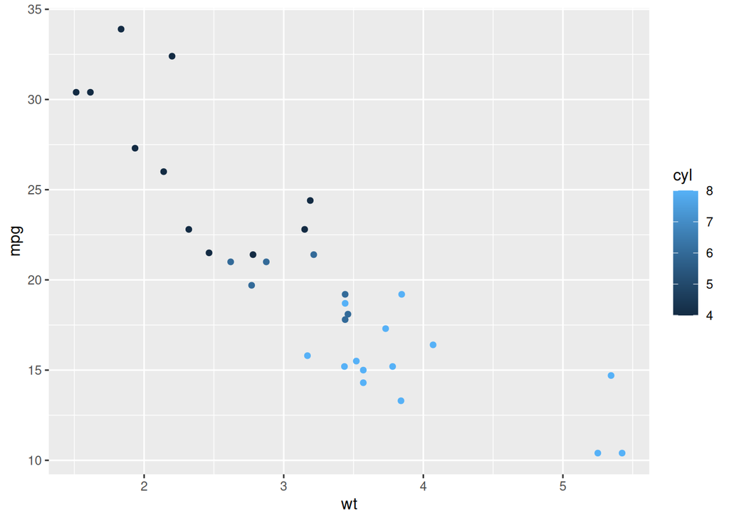

```r
# TODO: Color points by number of cylinders (cyl)
# Hint: put color = cyl inside aes(...)
# Note: removed hashtages in ggplot and geom so that R doesn't ignore command.
 ggplot(mtcars, aes(x = wt, y = mpg, color = cyl)) +
   geom_point()
```

```r
#Note: make all points one color
```

**Interpretation (2–4 sentences):**  
**TODO:** What does “mapping” mean here? What does the legend represent? - mapping means assigning a variable from the data (cyl) to create a an aesthetic for (color). Each point on the graph colors are determined by how many cylinders a particular car has. The legend shows which color goes to cylinder group it belongs in.

### 5.1 6) Set a constant color (NOT mapped)

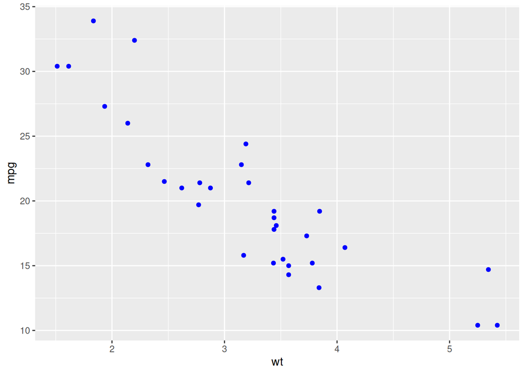

```r
# TODO: Make points blue (or any single color you like) BUT do not create a legend.
# Hint: put color = "blue" outside aes(...)
# Note: removed hashtags to make all plots all blue
 ggplot(mtcars, aes(x = wt, y = mpg)) +
  geom_point(color = "blue")
```

**Interpretation (1–2 sentences):**  
**TODO:** Explain why the previous plot had a legend but this one does not. - The previous plot had a legend because color was mapped to a variable (cyl) inside aes(), so ggplot needed a legend to explain the different colors. - In this plot, the color is set to a single value being (“blue”) that is outside aes(), so it does not represent any data. ### 7) Try other aesthetics

Choose ONE: - Map `size` to `hp`, OR - Map `shape` to `gear`, OR - Map `alpha` to `disp`

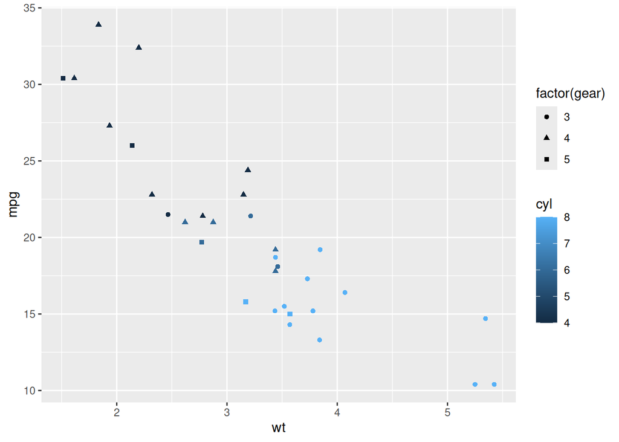

```r
# TODO: Make points green (or any single color you like) BUT do not create a legend.
# Hint: put color = "green" outside aes(...)

 ggplot(mtcars, aes(x = wt, y = mpg, color = cyl, shape = factor ( gear ))) + geom_point()
```

**Interpretation (2–4 sentences):**  
**TODO:** Was your chosen aesthetic helpful or confusing? Why? - My chosen aesthetic was confusing since changing the shape to gear makes it visually difficult to understand what the data is interpreting even though a legend is present. —

## 6 Part C — Break it on purpose, then fix it

### 6.1 8) “Object not found” in ggplot2

Run the code below **as is**. You should get an error.

```r
# DO NOT FIX THIS LINE YET — run it first and read the error.

#Note: added hashtags since it should give you an error but idn't want to have issues when knitting

# ggplot(mtcars, aes(x = weight, y = mpg)) +
#  geom_point()
```

**TODO:** Copy/paste the exact error message here:

Error in `geom_point()`: ! Problem while computing aesthetics. ℹ Error occurred in the 1st layer. Caused by error: ! object ‘weight’ not found Run `rlang::last_trace()` to see where the error occurred. >

Now fix it.

```r
# TODO: Fix the plot by using the correct column name.
# Hint: check names(mtcars)
# Note: changed weight to x= wt because it doesn't know weight
# Your fixed code here
ggplot(mtcars, aes(x = wt, y = mpg)) +
  geom_point()
```

## 7 Part D — Layers: add a trend line, then modify it

### 7.1 9) Add a smooth trend

Note: removed hashtags in lines 218 to 220

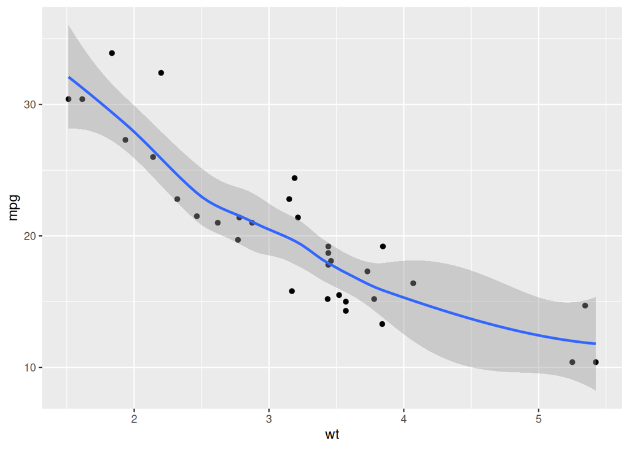

```r
# TODO: Add geom_smooth() to your scatterplot of wt vs mpg
# Hint: add a new layer with +
# Note: a solid line and a surrounding grey area usually represent a regression line and its confidence interval produced by geom_smooth() function.
 ggplot(mtcars, aes(wt, mpg)) +
   geom_point() +
   geom_smooth()
```

### 7.2 10) Make the smooth line a *linear model*

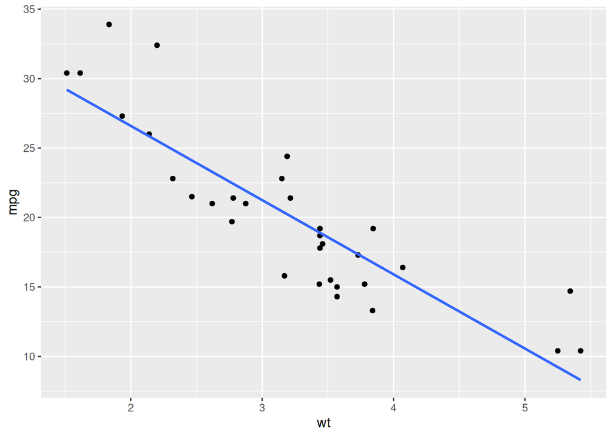

```r
# TODO: Modify geom_smooth so it fits a straight line.
# Hint: geom_smooth(method = "lm", se = FALSE)
# Note: what does se: false do? turns confidence intervals off
# Note: added new code for smooth linear line
# Your code here
ggplot(mtcars, aes (x = wt, y= mpg)) +
   geom_point() +
   geom_smooth(method ="lm", se = FALSE)
```

**Interpretation (2–4 sentences):**  
**TODO:** What does `se = FALSE` change? Why might you turn it off? - ‘se = FALSE’ removes the shaded confidence interval ribbon around the regression line to make the plot look cleaner visually. —

## 8 Part E — Facets: small multiples

### 8.1 11) Compare groups with facets

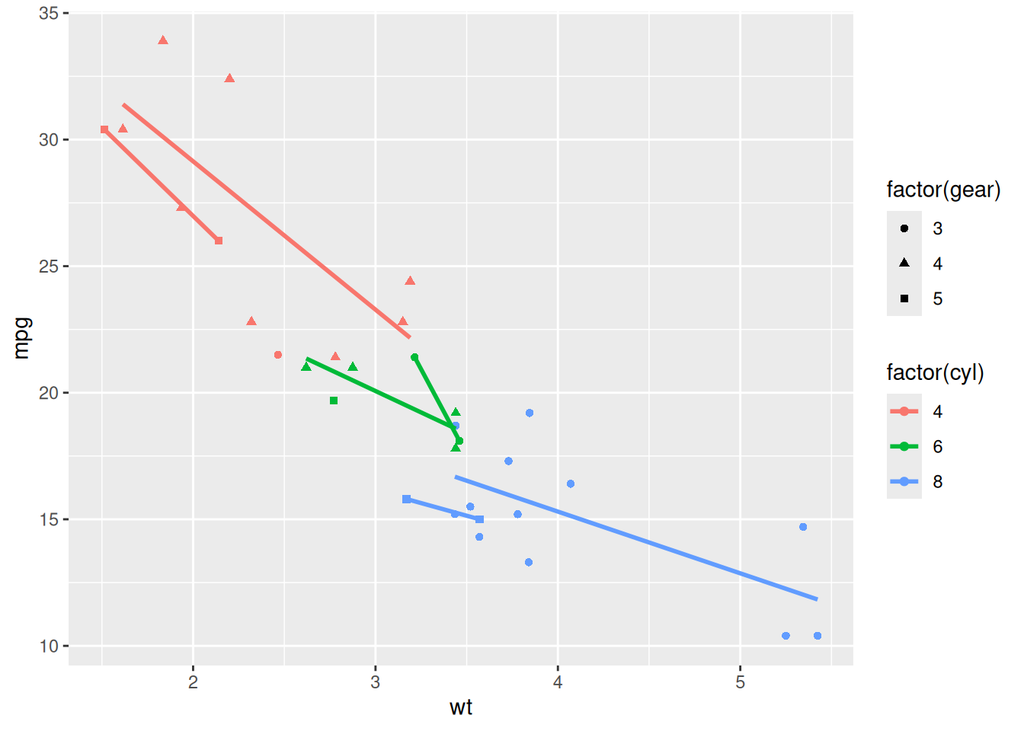

```r
# TODO: Facet by cylinders (cyl)
# Hint: + facet_wrap(~ cyl)
# Note: edit all this
# Your code here
ggplot(mtcars, aes(wt, mpg, color = factor (cyl), shape = factor (gear))) + geom_point() +
   geom_smooth(method ="lm", se = FALSE)
```

```r
   facet_wrap(~cyl)
```

[output not shown]

**Interpretation (2–4 sentences):**  
**TODO:** In what way is faceting different from coloring? Which is clearer here? - faceting allows to plot in grids to show a different subset of data in a specific category. - coloring is more clearer when showing differences and direct comparisons while faceting prevents overlap of data points. —

## 9 Part F — Labels, themes, and coordinate systems

### 9.1 12) Make it readable (labels + theme)

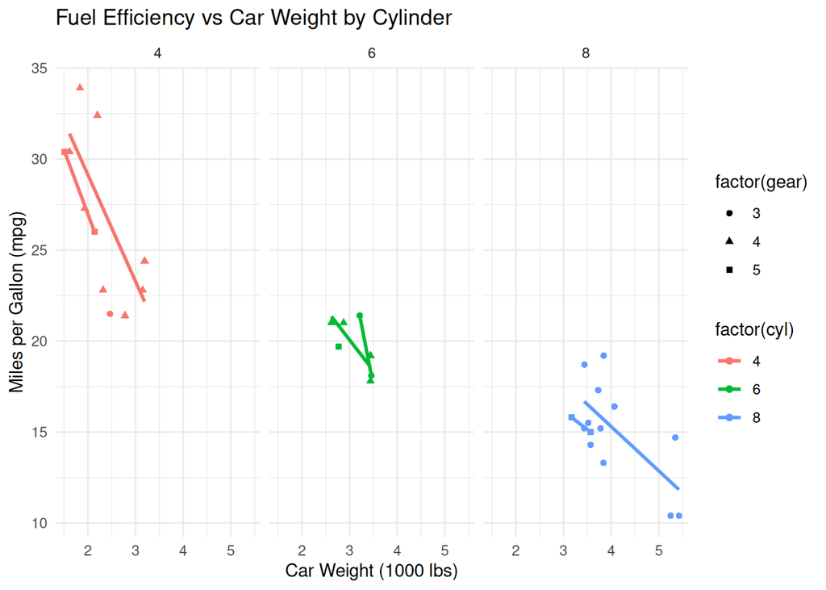

```r
# TODO: Improve your plot.
# Requirements:
# - Add a title
# - Label x and y axes with words (not just wt/mpg)
# - Use theme_minimal() OR theme_classic()

# Your code here
   ggplot(mtcars, aes(wt, mpg, color = factor(cyl), shape = factor(gear))) +
  geom_point() +
  geom_smooth(method = "lm", se = FALSE) +
  facet_wrap(~ cyl) +
  labs(
    title = "Fuel Efficiency vs Car Weight by Cylinder",
    x = "Car Weight (1000 lbs)",
    y = "Miles per Gallon (mpg)"
  ) +
  theme_minimal()
```

**Interpretation (2–4 sentences):**  
**TODO:** What design choices did you make and why? - Design choices I made to this graph is include a title on the top, title on both (x and y) axis. - This helped make the graph more visually appealing but also include the necessary information it needed to understand what the plot is interpreting. ### 13) Coordinate systems: zoom vs change scale

**A. Zoom (keep the data, change what you *see*)**

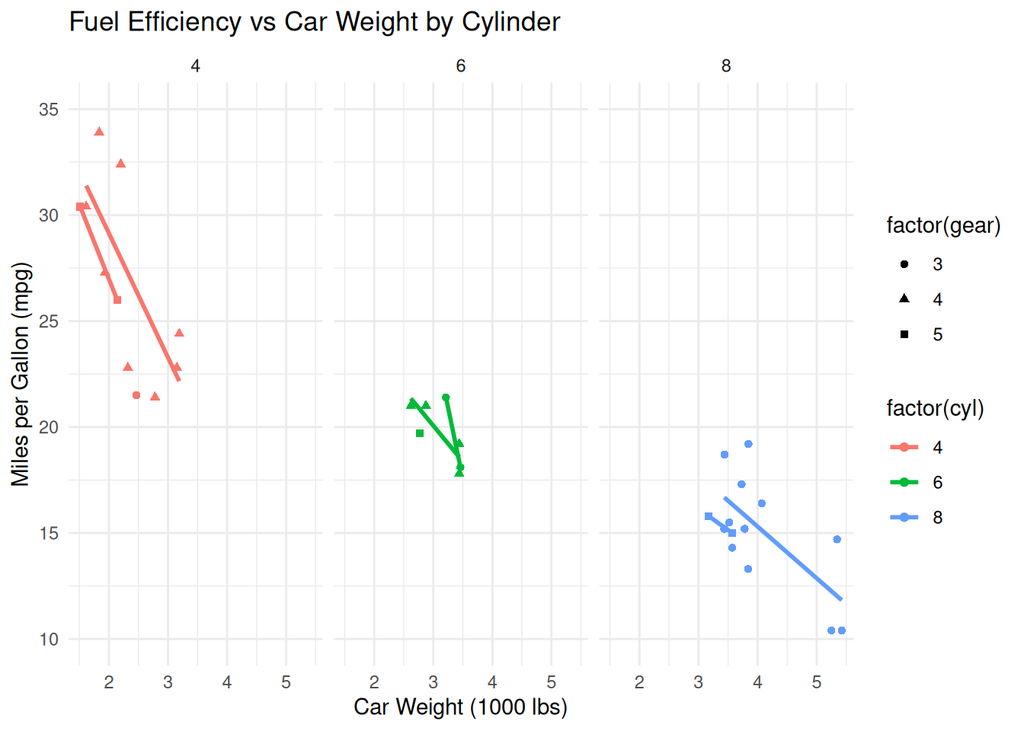

```r
# TODO: Add coord_cartesian(ylim = c(10, 35)) (or similar)
# Use your favorite plot from above.
# Note: addded coord_cartesian as extended function in chunk. Not really sure what it did.
# Your code here
ggplot(mtcars, aes(wt, mpg, color = factor(cyl), shape = factor(gear))) +
  geom_point() +
  geom_smooth(method = "lm", se = FALSE) +
  facet_wrap(~ cyl) +
  labs(
    title = "Fuel Efficiency vs Car Weight by Cylinder",
    x = "Car Weight (1000 lbs)",
    y = "Miles per Gallon (mpg)"
  ) +
  coord_cartesian(ylim = c(10, 35)) +
  theme_minimal()
```

**B. Filter (remove data before plotting)**

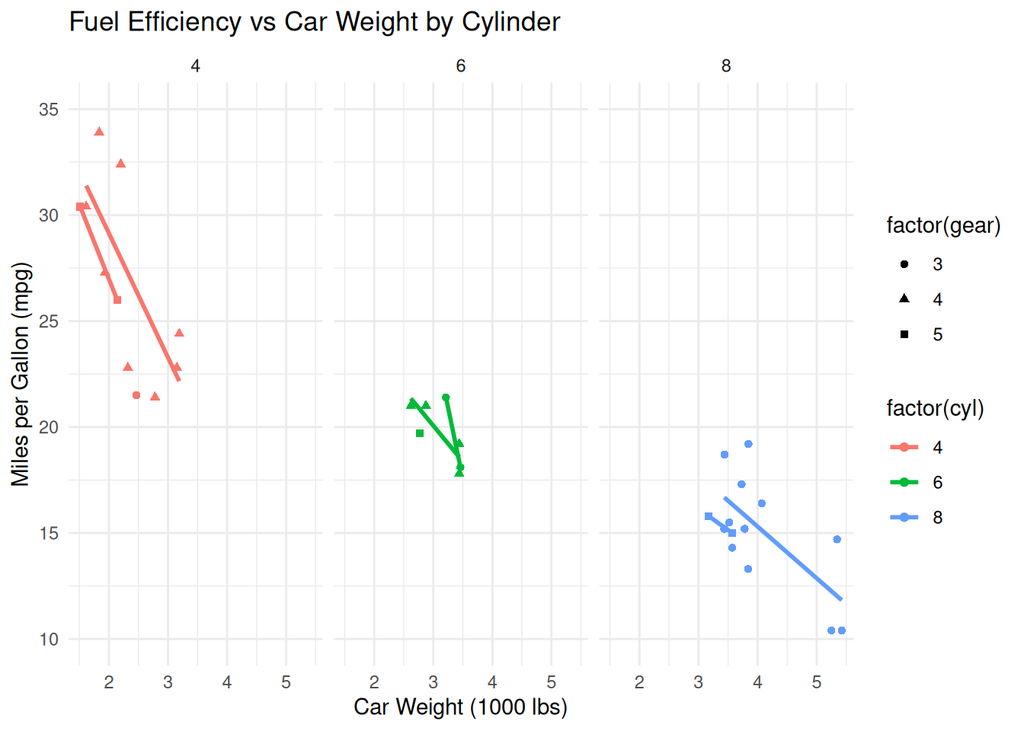

```r
# TODO: Create a filtered dataset that keeps only cars with mpg <= 35 (or similar),
# then plot it. You may use base R or dplyr.

# Option 1 (base R):
# mt_small <- mtcars[mtcars$mpg <= 35, ]

# Option 2 (dplyr):
# mt_small <- mtcars %>% filter(mpg <= 35)
# Note: option 1: 32 observations empty_small of 11 variables
# Note: add $
# Your code here
# Note: did option 1

ggplot(mtcars, aes(wt, mpg, color = factor(cyl), shape = factor(gear))) +
  geom_point() +
  geom_smooth(method = "lm", se = FALSE) +
  facet_wrap(~ cyl) +
  labs(
    title = "Fuel Efficiency vs Car Weight by Cylinder",
    x = "Car Weight (1000 lbs)",
    y = "Miles per Gallon (mpg)"
  ) +
  coord_cartesian(ylim = c(10, 35)) +
  theme_minimal()
```

```r
  mt_small <- mtcars[mtcars$mpg <= 35, ]

ggplot(mt_small, aes(wt, mpg)) +
  geom_point()
```

[output not shown]

**Interpretation (3–5 sentences):**  
**TODO:** Explain the difference between *zooming* with `coord_cartesian()` and *filtering* the data first. Why does this matter ethically? - “Zooming” with coord_cartesian() restricts how we view the window of a plot while keeping the entire dataset intact - It acts as a magnifier. Examples could be trends, smoothers, etc. - “filtering” data first removes data points outside the specified range before plotting - This can change the statistical summaries and visual interpretations of the graphs created. This matters ethically because filtering unaware can lead to the removal of outliers or contextual information.

## 10 Part G — Final challenge (choose one)

Pick ONE challenge below and complete it. Your goal is to show you can build a plot, break it, and rebuild it.

### 10.1 Option 1: Boxplot + jitter

Note: add boxplot and jitter piece Note: geombox + jitter code Note: x=cylinder y=mpg Note: not doing geom or facet Make a boxplot of `mpg` by `cyl`, then overlay jittered points. # Note: included geom_boxplot and geom_jitter

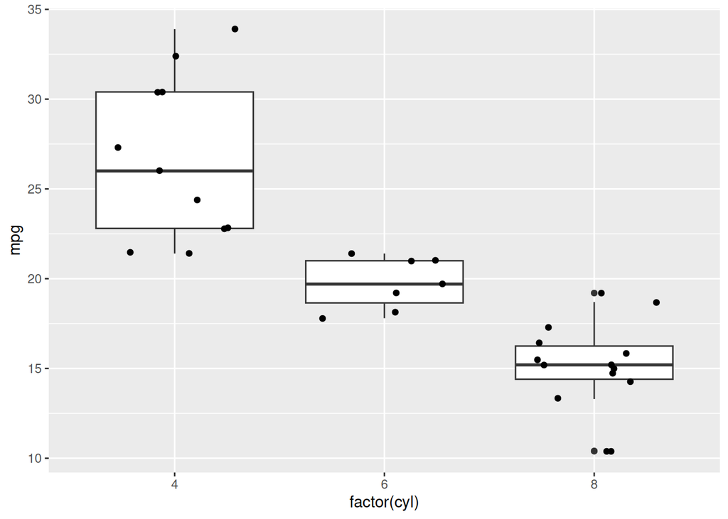

```r
# TODO: Your code here
ggplot(mtcars, aes(x = factor(cyl), y = mpg)) +
  geom_boxplot() +
  geom_jitter(width = 0.3)
```

**Interpretation (2–4 sentences):**  
**TODO:** What does the boxplot summarize that the points do not (or vice versa)? - Boxplot summarizes and shows points in the median, quartiles and interquartile range (IQR). - In doing so, it provides immediate visual cues for overall spread and skewness, which can be difficult to tell without it.

## 11 Turn‑in checklist

Before you submit:

- You knitted to **HTML** with no errors.
- Every **TODO** section has either code or prose.
- Your plots appear in the knitted HTML.
- Your interpretations are in your own words.